# Evaluating US Carbon Emissions

The Intergovernmental Panel on Climate Change released a [report](https://www.ipcc.ch/sr15/chapter/spm/) that highlights the dangerous impacts of global warming of 1.5°C above pre-industrial levels due to excessive anthropogenic emissions. The general population may agree that action must be taken now, but the specific actions taken may not be so agreeable. After all, the emissions produced per any given person and activity may greatly.

With that in mind, who should be held accountable for reducing their emissions? Is it you?

This notebook breaks down United States dataset emissions by the state, sector, and year to gain a better understanding on the who, what, and when. Data is taken from the United States [Energy Information Administration](https://www.eia.gov/) (EIA) API, spanning 30 years across 50 states (plus DC) with three different sectors: commercial, industrial, and residential. This notebook will answer the following questions:

- Are national emissions increasing every year?
- Which sector produces the most emissions?
- Which state produces the most emissions?

For reference, the residential sector include housing such as single-family homes and high-rise apartments, while the commercial sector encompasses offices and other commerce buildings like hotels, schools, or hospitals. The industrial sector encompass buildings and equipment that manufacture goods, such as general construction, an automobile factory, or farm.

## Loading Data

For this notebook, a .json file was downloaded from the EIA API to evaluate. The raw data file is filtered to contain the following columns:

- Year from 1990 to 2020
- Commercial, Industrial, or Residential
- State
- Mt (million metric tonnes) of CO2

Let's begin by bringing in our data. This is done by translating the json file over to a dataframe.

```python
import json
data_json = open('data.json')
data_raw = json.load(data_json)
data_json.close()
data = data_raw['response']['data']

import pandas as pd
df_raw = pd.DataFrame.from_dict(data)
df_raw
```

|  | period | sectorId | sector-name | fuelId | fuel-name | stateId | state-name | value | value-units |
| --- | --- | --- | --- | --- | --- | --- | --- | --- | --- |
| 0 | 2008 | CC | Commercial carbon dioxide emissions | TO | All Fuels | WV | West Virginia | 1.564893 | million metric tons of CO2 |
| 1 | 2008 | IC | Industrial carbon dioxide emissions | TO | All Fuels | WV | West Virginia | 13.061528 | million metric tons of CO2 |
| 2 | 2009 | RC | Residential carbon dioxide emissions | TO | All Fuels | WV | West Virginia | 1.827384 | million metric tons of CO2 |
| 3 | 2009 | CC | Commercial carbon dioxide emissions | TO | All Fuels | WV | West Virginia | 1.542645 | million metric tons of CO2 |
| 4 | 2009 | IC | Industrial carbon dioxide emissions | TO | All Fuels | WV | West Virginia | 9.037043 | million metric tons of CO2 |
| ... | ... | ... | ... | ... | ... | ... | ... | ... | ... |
| 4831 | 2012 | CC | Commercial carbon dioxide emissions | TO | All Fuels | ND | North Dakota | 1.216675 | million metric tons of CO2 |
| 4832 | 2012 | IC | Industrial carbon dioxide emissions | TO | All Fuels | ND | North Dakota | 15.900585 | million metric tons of CO2 |
| 4833 | 2013 | RC | Residential carbon dioxide emissions | TO | All Fuels | ND | North Dakota | 1.119325 | million metric tons of CO2 |
| 4834 | 2013 | CC | Commercial carbon dioxide emissions | TO | All Fuels | ND | North Dakota | 1.585363 | million metric tons of CO2 |
| 4835 | 2013 | IC | Industrial carbon dioxide emissions | TO | All Fuels | ND | North Dakota | 16.211566 | million metric tons of CO2 |

4836 rows × 9 columns

## Cleaning Data

Before we dive further, let's first investigate the column names. At first glance, there appears to be too many of them. Do they align with what we're looking for? Let's take a look.

- **period**: year
- **sectorId**: commerical (CC), industrial (IC), and residential (RC) sector abbreviation
- **sector-name**: commerical (CC), industrial (IC), and residential (RC) sector full name
- **fuelId**: all fuels abbreviation
- **fuel-name**: all fuels
- **stateId**: state abbreviation
- **state-name**: state name
- **value**: emission value
- **value-units**: million metric tons of CO2

The red values above are the column names that are not needed to evaluate the dataset. The units are the same across all values, so `value-units` is not needed. Furthermore, it is redundant to have the full name and abbreviation, so `sector-name` and `state-name` are removed. For this data set, we are evlauting emissions across the given API category 'all fuels', so `fuelID` and `fuel-name` are not needed. However, they could be utilized in the event that this notebook were to be replicated with different fuel sources, like coal and natural gas. It would also be good practice to make the data more readable. The column names could be changed to be more intuitive.

With all of this in mind, the data can be cleaned by:

- removing the above columns
- changing the names of the existing columns

Run the code below to give it a try.

```python
def cleaning_df(df):
    # putting in assertions in case this is ran twice
    assert 'sector-name' in df.columns
    assert 'fuelId' in df.columns
    assert 'fuel-name' in df.columns
    assert 'state-name' in df.columns
    assert 'value-units' in df.columns
    # if there is an assertion error, make sure to run the importing data cell again

    df.drop(['sector-name', 'fuelId', 'fuel-name', 'state-name', 'value-units'], axis = 1, inplace = True)
    df.rename(columns = {'period': 'year', 'sectorId': 'sector', 'stateId': 'state', 'value': 'Mt-CO2'}, inplace = True)

    return df

df = cleaning_df(df_raw)
df
```

|  | year | sector | state | Mt-CO2 |
| --- | --- | --- | --- | --- |
| 0 | 2008 | CC | WV | 1.564893 |
| 1 | 2008 | IC | WV | 13.061528 |
| 2 | 2009 | RC | WV | 1.827384 |
| 3 | 2009 | CC | WV | 1.542645 |
| 4 | 2009 | IC | WV | 9.037043 |
| ... | ... | ... | ... | ... |
| 4831 | 2012 | CC | ND | 1.216675 |
| 4832 | 2012 | IC | ND | 15.900585 |
| 4833 | 2013 | RC | ND | 1.119325 |
| 4834 | 2013 | CC | ND | 1.585363 |
| 4835 | 2013 | IC | ND | 16.211566 |

4836 rows × 4 columns

## Exploring Data

Now that the data is clean, the dataset can now be explored. Let's go through a few different exploration tactics.

```python
import numpy as np

def explore_data(df, col):
    list_unsorted = df[col].unique()
    list_sorted = np.sort(list_unsorted)
    return list_sorted

print(f'Total rows of dataframe: {len(df)} rows\n')

years = explore_data(df, 'year')
print(f'List of {len(years)} years:\n{years}\n')

states = explore_data(df, 'state')
print(f'List of {len(states)} states:\n{states}')
print('Note that US = United States, and DC = District of Columbia.\n')

print('Statistics of Mt-CO2:')
df['Mt-CO2'].describe()
```

```
Total rows of dataframe: 4836 rows

List of 31 years:
[1990 1991 1992 1993 1994 1995 1996 1997 1998 1999 2000 2001 2002 2003
 2004 2005 2006 2007 2008 2009 2010 2011 2012 2013 2014 2015 2016 2017
 2018 2019 2020]

List of 52 states:
['AK' 'AL' 'AR' 'AZ' 'CA' 'CO' 'CT' 'DC' 'DE' 'FL' 'GA' 'HI' 'IA' 'ID'
 'IL' 'IN' 'KS' 'KY' 'LA' 'MA' 'MD' 'ME' 'MI' 'MN' 'MO' 'MS' 'MT' 'NC'
 'ND' 'NE' 'NH' 'NJ' 'NM' 'NV' 'NY' 'OH' 'OK' 'OR' 'PA' 'RI' 'SC' 'SD'
 'TN' 'TX' 'US' 'UT' 'VA' 'VT' 'WA' 'WI' 'WV' 'WY']
Note that US = United States, and DC = District of Columbia.

Statistics of Mt-CO2:
```

```
count    4836.000000
mean       20.395229
std        88.507186
min         0.017156
25%         2.001510
50%         4.590473
75%        12.312540
max      1127.981768
Name: Mt-CO2, dtype: float64
```

## Analyzing Data

There are three different factors to consider here: states (51), year (31), and sector (3). Let's break this into pieces to continue exploring our data and receive a visual answer to our questions.

First, let's separate our data into three different variables that correspond to each of the three sectors. The sectors were chosen due to its smaller size in comparison to states and year. The variables below will be used throughout the notebook.

```python
def separate_sector(df, sector):
    df_sector = df.loc[df['sector'] == sector].reset_index().drop(['sector', 'index'], axis = 1)
    return df_sector

df_com = separate_sector(df, 'CC')
df_ind = separate_sector(df, 'IC')
df_res = separate_sector(df, 'RC')
```

```python
# Running an example - feel free to pick and choose here
display(df_ind)
```

|  | year | state | Mt-CO2 |
| --- | --- | --- | --- |
| 0 | 2008 | WV | 13.061528 |
| 1 | 2009 | WV | 9.037043 |
| 2 | 2010 | WV | 10.542959 |
| 3 | 2011 | WV | 10.671985 |
| 4 | 2012 | WV | 9.957832 |
| ... | ... | ... | ... |
| 1607 | 1994 | IA | 14.831733 |
| 1608 | 1995 | IA | 15.178980 |
| 1609 | 2011 | ND | 15.303989 |
| 1610 | 2012 | ND | 15.900585 |
| 1611 | 2013 | ND | 16.211566 |

1612 rows × 3 columns

Let's see what the data could look like if we change year (range of 31) and sectors (range of 3) but keep the states constant (51). In other words, what does the total emissions look like for the entire US given the year and sector? The first step would be to prepare our data so we get our filtered results, seen below.

```python
def separate_sector_state(df_sector, state):
    df_sector_state = df_sector.loc[df_sector['state'] == state].sort_values(by = ['year'])
    df_sector_state = df_sector_state.reset_index().drop(['index', 'state'], axis = 1)
    return df_sector_state

df_ind_us = separate_sector_state(df_ind, 'US')
df_com_us = separate_sector_state(df_com, 'US')
df_res_us = separate_sector_state(df_res, 'US')
```

```python
# Running an example
df_ind_us.head()
```

|  | year | Mt-CO2 |
| --- | --- | --- |
| 0 | 1990 | 1052.884967 |
| 1 | 1991 | 1019.786031 |
| 2 | 1992 | 1067.436584 |
| 3 | 1993 | 1059.490572 |
| 4 | 1994 | 1073.944612 |

The data is ready to be visualized. Let's import `matplotlib` to plot the total US emissions over the given time span, broken down by the three sectors.

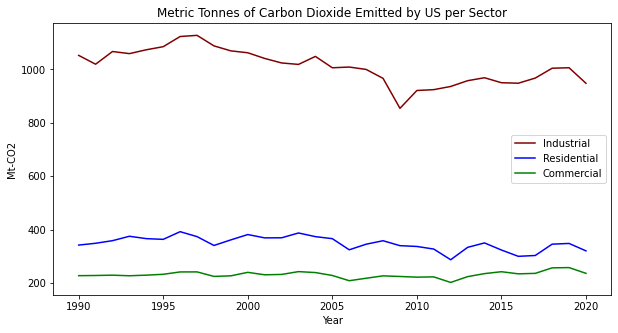

```python
import matplotlib.pyplot as plt

plt.figure(figsize = (10, 5))
plt.plot(df_ind_us['year'], df_ind_us['Mt-CO2'], color = 'maroon', label = 'Industrial')
plt.plot(df_res_us['year'], df_res_us['Mt-CO2'], color = 'blue', label = 'Residential')
plt.plot(df_com_us['year'], df_com_us['Mt-CO2'], color = 'green', label = 'Commercial')
plt.legend(loc="center right")
plt.xlabel("Year")
plt.ylabel("Mt-CO2")
plt.title(f"Metric Tonnes of Carbon Dioxide Emitted by US per Sector")
plt.show()

??plt
```

Based on the graph above, the Industrial sector produces the most emissions.

It is a bit more unclear when determining if total US emissions have increased during this time period. Further analysis would need to be conducted to obtain a more concrete answer, but based on visual examination alone, there doesn't seem to be a significiant growth in US emissions. Exploring why would be outside the breadth of this notebook, but possible factors include using less energy (increased energy efficiency programs, stagnant population/demand) and cleaner energy supply (renewable energy, replacing old coal plants).

In the analysis above, sectors and year are considered, but not states. Now let's look at when sectors (range of 3) and states (range of 51) are changing, but the year remains constant (2020). The functions below prepares and visualizes this data.

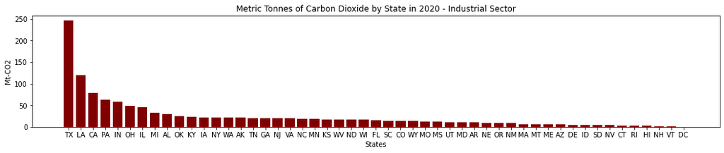

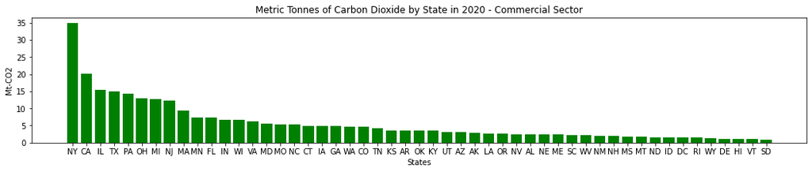

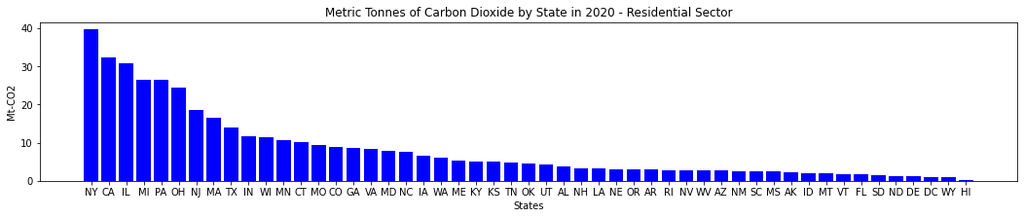

```python
def bar_graph_2020(df_sector_year, custom_color, sector):
    plt.figure(figsize = (18, 3))
    plt.bar(df_sector_year['state'], df_sector_year['Mt-CO2'], color = custom_color)
    plt.xlabel('States')
    plt.ylabel('Mt-CO2')
    plt.title(f'Metric Tonnes of Carbon Dioxide by State in 2020 - {sector} Sector')
    return plt.show()

def remove_us(df):
    return df[df['state'].str.contains('US') == False].sort_values('Mt-CO2', ascending = False)

bar_ind_2020 = bar_graph_2020(remove_us(df_ind), 'maroon', 'Industrial')
bar_com_2020 = bar_graph_2020(remove_us(df_com), 'green', 'Commercial')
bar_res_2020 = bar_graph_2020(remove_us(df_res), 'blue', 'Residential')
```

In this year, which states contributes the most? It depends on the sector. Texas, Lousiana, and California appear to be the top 3 states who contribute the most in the industrial sector. New York, California, and Illinois appear to be the top 3 states who contribute the most in the Residential and Commercial sector. However, it is likely that state density influences the emission results. For the purpose of this notebook, we will continue as-is with the absolute numbers, but a per-capita number may better be better suited in future analysis.

Finally, let's look at when states and years are considered, but not sector. Right away, we run into a predicament: how do we best visualize this? After all, there are 30 years and 51 states to consider. We could have a line graph with the x-axis as the year, the y-axis as Mt-CO2, and the states as the series. However, with 51 lines on the graph, the visual would be hard to read and dephicer. We need a different, cleaner method of visualizing this.

Instead of representing three factors (states, sectors, years) in one still image, consider capturing two factors (states, sectors) with a series of images, each image representing a single year. In other words, let's try animating our results.

Although downloading external packages are not recommended, I found a module named `bar_chart_race` that I thought would be great for this assignment. **For auto-grading purposes, the code has been commented out - but the results are outputted below. Please note that this part is supplementary and not necessary for analysis.**

The official documentation can be found [here](https://www.dexplo.org/bar_chart_race/). Because this is a newer module, Vocareum does not have the module in their server. Let's install the module before importing it.

```python
# # Please run before proceeding. It may take a minute to complete.
# !pip install bar-chart-race
```

Before diving into the module, the data must further be cleaned. The documentation states that the input data must be in wide format; right now, the data is in long format. The function below solves this by pivoting the dataframe to wide format.

```python
def long_to_wide(df_long):
    df_wide = df_long.pivot(index = 'year', columns = 'state', values = 'Mt-CO2').drop(['US'], axis = 1)
    return df_wide
```

```python
# Running an example
long_to_wide(df_ind).head()
```

| state year | AK | AL | AR | AZ | CA | CO | CT | DC | DE | FL | ... | SD | TN | TX | UT | VA | VT | WA | WI | WV | WY |
| --- | --- | --- | --- | --- | --- | --- | --- | --- | --- | --- | --- | --- | --- | --- | --- | --- | --- | --- | --- | --- | --- |
| 1990 | 15.493280 | 24.653103 | 9.081758 | 3.785883 | 69.321237 | 6.901342 | 2.813309 | 0.036917 | 4.313397 | 11.838519 | ... | 2.085409 | 18.319662 | 209.582568 | 9.660312 | 19.319955 | 0.441107 | 16.514483 | 14.072958 | 17.661626 | 10.176367 |
| 1991 | 17.034494 | 24.871108 | 7.825306 | 3.842751 | 70.658061 | 7.773117 | 2.936560 | 0.025112 | 3.336935 | 11.123313 | ... | 1.999711 | 18.050888 | 207.349714 | 9.048273 | 19.673388 | 0.452769 | 15.468115 | 14.283229 | 15.457839 | 9.718283 |
| 1992 | 18.458355 | 27.891722 | 9.320674 | 3.850771 | 71.084086 | 8.020909 | 3.192036 | 0.031409 | 4.575411 | 12.772634 | ... | 1.924228 | 19.547678 | 212.974304 | 8.925129 | 18.551611 | 0.532770 | 17.871162 | 14.237964 | 14.717482 | 11.696730 |
| 1993 | 18.103114 | 26.477527 | 9.413394 | 3.862676 | 68.328206 | 8.700163 | 3.258218 | 0.022399 | 4.832660 | 14.008846 | ... | 2.291117 | 19.547251 | 214.533942 | 9.111937 | 16.980317 | 0.542225 | 15.663992 | 15.027549 | 15.330805 | 10.103797 |
| 1994 | 17.701835 | 27.388795 | 10.203112 | 4.252148 | 68.660760 | 8.203229 | 2.854628 | 0.033978 | 4.933120 | 14.759951 | ... | 2.444177 | 19.710148 | 217.285873 | 9.096985 | 17.268196 | 0.422811 | 17.970358 | 15.503749 | 16.168095 | 10.409704 |

5 rows × 51 columns

Now we're ready to run the bar chart race module to see how emissions change with states and year. **The below section is commented out since the module installation will not pass the auto-grader, but you are welcome to run it yourself in a separate notebook if you'd like.**

```python
# import bar_chart_race as bcr
# import warnings
# warnings.filterwarnings('ignore')

# def animate_bar_chart(df, title):
#     print('Please be patient; Python is composing the animation. This may take a minute or two.')
#     fig, ax = plt.subplots(figsize = (6, 2.5), dpi = 144)
#     ax.set_facecolor('.8')
#     ax.tick_params(labelsize = 7, length = 0)
#     ax.grid(True, axis = 'x', color = 'white')
# #     ax.set_axisbelow(True)
#     [spine.set_visible(False) for spine in ax.spines.values()]
#     fig.patch.set_facecolor('white')
#     fig.suptitle(title, y = 1)
#     animation = bcr.bar_chart_race(df,
#                        fig = fig,
#                        n_bars = 20,
#                        orientation = 'v',
#                        filter_column_colors = True,
#                        fixed_max = True,
#                        period_fmt = '{x: .0f}')
#     return animation

# animate_bar_chart(df = long_to_wide(df_ind),
#                   title = 'Top 20 Annual Mt-CO2 Emissions per State - Industrial Sector')
```

Below is a snippet of the video file. If Vocareum outputs this as a still image, feel free to open the .mp4 directly by going to the file path or right-clicking on the image to open video on a new tab. (Again, not necessary - this is supplementary information.)

[video not shown]

Instead of submitting the animation above two more times for Commercial and Residential, the sectors were instead combined into one graph that outputs the top 20 emittors for each sector-state. However, do feel free to change `df_ind` to `df_com` or `df_res` above to see how much the results change.

Below is a function that converts all sector data into wide format then merges it into one dataframe.

```python
from functools import reduce

def total_long_to_wide(df_long_com, df_long_ind, df_long_res):
    df_wide_com = long_to_wide(df_long_com).add_suffix('\ncom')
    df_wide_ind = long_to_wide(df_long_ind).add_suffix('\nind')
    df_wide_res = long_to_wide(df_long_res).add_suffix('\nres')
    data_frames = [df_wide_com, df_wide_ind, df_wide_res]
    df_wide_merged = reduce(lambda left, right:
                       pd.merge(left, right, left_index = True, right_index = True, how='outer'),
                       data_frames)
    return df_wide_merged
```

```python
# Running an example
total_long_to_wide(df_com, df_ind, df_res).head()
```

| state year | AK\ncom | AL\ncom | AR\ncom | AZ\ncom | CA\ncom | CO\ncom | CT\ncom | DC\ncom | DE\ncom | FL\ncom | ... | SD\nres | TN\nres | TX\nres | UT\nres | VA\nres | VT\nres | WA\nres | WI\nres | WV\nres | WY\nres |
| --- | --- | --- | --- | --- | --- | --- | --- | --- | --- | --- | --- | --- | --- | --- | --- | --- | --- | --- | --- | --- | --- |
| 1990 | 2.192144 | 2.439619 | 1.623072 | 1.901268 | 18.972358 | 3.987425 | 3.802631 | 1.242824 | 0.577723 | 6.259632 | ... | 1.368186 | 3.290515 | 12.993224 | 2.758575 | 6.477815 | 1.399037 | 3.550870 | 9.475812 | 2.414344 | 0.826661 |
| 1991 | 2.228815 | 2.003882 | 1.631041 | 1.833733 | 19.121081 | 4.287188 | 3.635257 | 1.371434 | 0.577605 | 5.984252 | ... | 1.206625 | 3.443847 | 13.144818 | 3.128222 | 6.357397 | 1.466887 | 3.839205 | 10.165676 | 2.335198 | 0.878553 |
| 1992 | 2.512641 | 2.112401 | 1.586913 | 1.777605 | 17.418581 | 4.117586 | 4.283629 | 1.373089 | 0.552356 | 5.967377 | ... | 1.024684 | 3.656736 | 12.709620 | 2.744076 | 6.935243 | 1.597251 | 3.498774 | 9.894309 | 2.467702 | 0.765322 |
| 1993 | 2.553839 | 2.057618 | 1.814904 | 1.739994 | 15.532481 | 4.277357 | 3.817015 | 1.445413 | 0.692071 | 4.785670 | ... | 1.249042 | 4.000605 | 13.455281 | 3.108971 | 7.141497 | 1.557834 | 4.170086 | 10.639171 | 2.538803 | 0.878406 |
| 1994 | 2.576854 | 2.060112 | 1.750406 | 1.830570 | 15.928121 | 4.072905 | 4.145646 | 1.426192 | 0.618225 | 4.360622 | ... | 1.166479 | 3.951858 | 12.601210 | 2.878148 | 7.067074 | 1.483332 | 4.219436 | 10.176080 | 2.535288 | 0.819942 |

5 rows × 153 columns

Now let's run the same bar chart race module to see the results. The output of the commented code is seen below. Again, feel free to open the video by right-clicking to open in a new tab.

```python
#animate_bar_chart(df = total_long_to_wide(df_com, df_ind, df_res),
#                  title = 'Top 20 Annual Mt-CO2 Emissions per State and Sector')
```

[video not shown]

This helps put the sectors, years, and state into perspective, and all of our questions have already been answered. However, there is still a cleaner way to visualize this. Can we illustrate a similar message in a more aesthetic way? A Choropleth map with the US map as the backdrop can be used to investigate further. This can be done by using the `plotly` module, with the official documentation for Choropleth maps found [here](https://plotly.com/python/choropleth-maps/).

Let's explore what this look like by running the cells below. Make sure to press the play button to start the animation.

```python
import plotly.express as px

def usa_animation(df):
    animation = px.choropleth(data_frame = df[df['state'].str.contains('US') == False],
                  locations = 'state',
                  locationmode = 'USA-states',
                  color = 'Mt-CO2',
                  color_continuous_scale = 'Viridis_r',
                  scope = 'usa',
                  animation_frame = 'year')
    return animation
```

```python
# Run for Industrial sector
usa_animation(df_ind)
```

[interactive chart not shown]

```python
# Run for Residential sector
usa_animation(df_res)
```

[interactive chart not shown]

```python
# Run for Commercial sector
usa_animation(df_com)
```

[interactive chart not shown]

## Conclusion

In this notebook, we were able to explore which sectors produce the most emissions, how emissions change over time, and which states produce the most emissions. We used data cleaning and preparation tools to output several visuals, spanning from a simple line graph to an animated Choropleth map.

More complex research and investigation can be done to answer the following ideas:

- The data set is not per capita. Which states emit the most when accounting for population?
- The Industry sector appears to emit the most, but what does that fully entail? Can this be analyzed by specific industry?
- Since emissions have been relatively stagnant the last three decades, can we isolate specific factors that keep this at a steady-state or even decrease emissions?

Additionally, further improvements to our visuals can be made to best illustrate the data. The last visualization still does not take into account a simple, intuitive way to display how the state and sector emissions change over time.

Overall, this was a fulfulling exploratory exercise that opens the door to interesting questions. I hope you enjoyed learning along with me!